# basicstats

Jigyasa_Arora

4/12/2021

```r
library(dplyr)
library(tidyr)
library(data.table)
library(ape)
library(stringr)
```

##quast results-no.of scaffolds + total microbial ORFs-

```r
quast<-read.csv("basicstats/quast_results_allsamples.csv")
allcontigs<-read.csv("basicstats/allsamples-totalnoofcontigs.txt",header=FALSE,sep=":")
allcontigs$V1<-gsub("filename-","",allcontigs$V1)
allcontigs$V1<-gsub(".fasta","",allcontigs$V1)
quast_allcontigs<-merge(quast,allcontigs,by.x="samples",by.y="V1")
colnames(quast_allcontigs)<-c("samples","all_count","mapped_count","percent_mapped","allcontig_count")

allcontigsabove1000<-read.csv("basicstats/allsamples-contigsabove1000bps.txt",header=FALSE,sep=":")
allcontigsabove1000$V1<-gsub("above1000-filename-","",allcontigsabove1000$V1)
allcontigsabove1000$V1<-gsub(".fasta","",allcontigsabove1000$V1)
quast_allcontigs2<-merge(quast_allcontigs,allcontigsabove1000,by.x="samples",by.y="V1")
colnames(quast_allcontigs2)<-c("samples","all_count","mapped_count","percent_mapped","allcontig_count","contigabove1000_count")

allcontigsmicrobialabove1000<-read.csv("basicstats/allsamples-microbialabove1000bps.txt",header=FALSE)
quast_allcontigs3<-merge(quast_allcontigs2,allcontigsmicrobialabove1000,by.x="samples",by.y="V1")
colnames(quast_allcontigs3)<-c("samples","all_count","mapped_count","percent_mapped","allcontig_count","contigabove1000_count","microbialcontigs_above1000_count")

write.csv(quast_allcontigs3,file="basicstats/quast_results_allsamples_allcounts.csv")

#-----------------------------------------------------------------------------------------------------
quast_all<-read.csv("basicstats/quast_results_allsamples_allcounts.csv",row.names = 1)

print(paste0("shotgun sequencing generated on average= ",mean(quast_all$all_count), " reads"))
```

```
## [1] "shotgun sequencing generated on average= 72455879.890411 reads"
```

```r
print(paste0("shotgun sequencing generated on average= ",mean(quast_all$contigabove1000_count), " scaffolds above 1000bps"))
```

```
## [1] "shotgun sequencing generated on average= 92237.3287671233 scaffolds above 1000bps"
```

```r
print(paste0("shotgun sequencing generated on average= ",sum(quast_all$mapped_count)/sum(quast_all$all_count)*100, "% of mapped reads"))
```

```
## [1] "shotgun sequencing generated on average= 63.5748247068534% of mapped reads"
```

##samtools results-%mapped reads to GTDB prokaryotic contigs

```r
quast<-read.csv("basicstats/quast_results_allsamples_allcounts.csv")
mappedreads<-read.csv("basicstats/all-prokmapped-reads.txt",header=FALSE,sep="\t")
colnames(mappedreads)<-c("samples","prokmappedreads")

quast_prokmappedreads<-merge(quast,mappedreads,by="samples")
write.csv(quast_prokmappedreads,file="basicstats/quast_results_allsamples_allcounts_mappedreads.csv")
sampleinfo<-read.csv("taxonomy/sample_names_ids_withotherfactors_tomedit.2.csv")

quast_prokmappedreads2<-merge(quast_prokmappedreads,sampleinfo,by.x="samples",by.y="samples")

#stats-
lower<-quast_prokmappedreads2%>%filter(higher_lower=="lower") #also includes Cryptocercus cockroach
lower2<-quast_prokmappedreads2%>%filter(higher_lower=="lower" & samples!="229-08") #not includes Cryptocercus cockroach
higher<-quast_prokmappedreads2%>%filter(higher_lower=="higher")
wood_higher<-quast_prokmappedreads2%>%filter(diet_type_number4=="2")
soil_higher<-quast_prokmappedreads2%>%filter(diet_type_number4=="3")
fungus_higher<-quast_prokmappedreads2%>%filter(diet_type_number4=="5")

##mean values-
print(paste0("percentage of reads mapped to microbial contigs in all higher termites is ", sum(higher$prokmappedreads)/sum(higher$all_count)*100))
```

```
## [1] "percentage of reads mapped to microbial contigs in all higher termites is 20.5169244218129"
```

```r
print(paste0("percentage of reads mapped to microbial contigs in lower termites+Cryptocercus is ",sum(lower$prokmappedreads)/sum(lower$all_count)*100))
```

```
## [1] "percentage of reads mapped to microbial contigs in lower termites+Cryptocercus is 18.5626168381119"
```

```r
print(paste0("percentage of reads mapped to microbial contigs in lower termites is ",sum(lower2$prokmappedreads)/sum(lower2$all_count)*100))
```

```
## [1] "percentage of reads mapped to microbial contigs in lower termites is 18.4307215704815"
```

```r
print(paste0("percentage of reads mapped to microbial contigs in wood-feeding higher termites is ", sum(wood_higher$prokmappedreads)/sum(wood_higher$all_count)*100))
```

```
## [1] "percentage of reads mapped to microbial contigs in wood-feeding higher termites is 34.0190453750483"
```

```r
print(paste0("percentage of reads mapped to microbial contigs in soil-feeding higher termites is ", sum(soil_higher$prokmappedreads)/sum(soil_higher$all_count)*100))
```

```
## [1] "percentage of reads mapped to microbial contigs in soil-feeding higher termites is 12.2315808101432"
```

```r
print(paste0("percentage of reads mapped to microbial contigs in fungal feeding higher termites is ", sum(fungus_higher$prokmappedreads)/sum(fungus_higher$all_count)*100))
```

```
## [1] "percentage of reads mapped to microbial contigs in fungal feeding higher termites is 28.3437733601286"
```

##which samples to choose for statistical analysis-

```r
#criteria-%mapped reads to prokaryotic contigs, no.of prokaryotic contigs, prevelance-
quast_all<-read.csv("basicstats/quast_results_allsamples_allcounts.csv",row.names = 1)
#1. samples with >=10,000 contigs longer than 1000bps
quast_cri1<-quast_all%>%filter(contigabove1000_count>=10000) #& microbialcontigs_above1000_count >=1000)

print(paste0("There are ", nrow(quast_cri1), " no. of metagenomes with more than equal to 10,000 contigs above 1000 bps"))
```

```
## [1] "There are 129 no. of metagenomes with more than equal to 10,000 contigs above 1000 bps"
```

```r
#generate a tree from 129 samples-
termitetree<-read.tree("basicstats/rna12-16S_concensus_may2020_newnames.nwk")
d<-data.frame(label=termitetree$tip.label)
d$samples<-unlist(lapply(strsplit(as.character(d$label),split="-"),"[",1))
d$samples<-gsub("_","-",d$samples)

tipstokeep<-d%>%filter(samples %in% quast_cri1$samples)
termitetree_129samples<-keep.tip(termitetree,as.vector(tipstokeep$label))
write.tree(termitetree_129samples,file="1000bps_taxonomy_129taxa_tree.nwk")

#2. minimum no. of prokaryotic contigs in criteria1 samples-
print(paste0("There are a minimum of ",min(quast_cri1$microbialcontigs_above1000_count), " microbial contigs in 129 samples."))
```

```
## [1] "There are a minimum of 867 microbial contigs in 129 samples."
```

```r
print(paste0("There are a mean of ",mean(quast_cri1$microbialcontigs_above1000_count), " microbial contigs in 129 samples."))
```

```
## [1] "There are a mean of 25550.488372093 microbial contigs in 129 samples."
```

```r
print(paste0("There are a maximum of ",max(quast_cri1$microbialcontigs_above1000_count), " microbial contigs in 129 samples."))
```

```
## [1] "There are a maximum of 123171 microbial contigs in 129 samples."
```

```r
#3.number of microbial ORFs in the 129 samples-
#for i in proteinnames-*.txt;do  wc -l ${i} | awk '{print $1-1}' > numberof_microbialORFs_${i}.txt;done
#for i in numberof_microbialORFs_proteinnames-*;do awk '{print FILENAME"\t"$0}' ${i} > 2-${i};done
#cat 2-numberof_microbialORFs_proteinnames-* > allnumberof_microbialORFs.txt

microbialorfs<-read.csv("basicstats/allnumberof_microbialORFs.txt",header=FALSE,sep="\t")
microbialorfs$V1<-gsub("numberof_microbialORFs_proteinnames-","",microbialorfs$V1)
microbialorfs$V1<-gsub(".txt.txt","",microbialorfs$V1)
microbialorfs<-microbialorfs%>%filter(V1 %in% quast_cri1$samples)

print(paste0("The mean Open reading frames in microbial contigs are ", mean(microbialorfs$V2)))
```

```
## [1] "The mean Open reading frames in microbial contigs are 127159.209302326"
```

```r
allorfs<-read.csv("basicstats/allnumberof_ORFs.txt",header=FALSE,sep="\t")
allorfs$V1<-gsub("numberofORFs_filename-","",allorfs$V1)
allorfs$V1<-gsub("-prokka.faa-smallername.faa.txt","",allorfs$V1)
allorfs<-allorfs%>%filter(V1 %in% quast_cri1$samples)

print(paste0("The mean Open reading frames in all contigs are ", mean(allorfs$V2)))
```

```
## [1] "The mean Open reading frames in all contigs are 373744.713178295"
```

##prevalance/cut-offs used for statistical analysis-

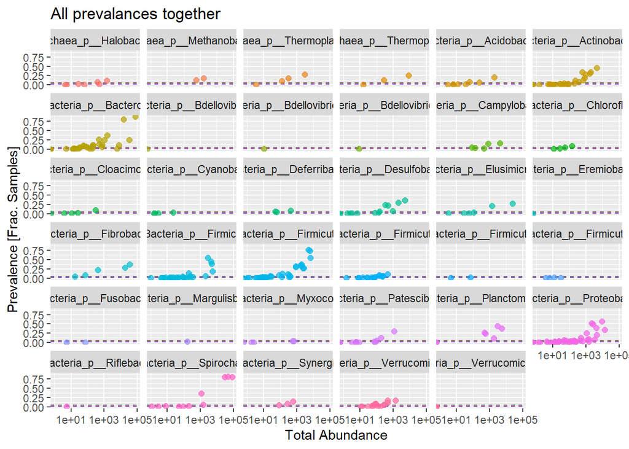

```r
#4. prevalence of phyla from the markergene data-
markergenes<-read.csv("taxonomy/all-cogs-taxonomy-contiginfo-tpm-filtered-corrected.csv",row.names=1) #generated from "taxonomy_march2021.Rmd"
markergenes$phyla<-gsub("_c__.*$","",markergenes$taxonomy)
markergenes$family<-gsub("_g__.*$","",markergenes$taxonomy)


##by phyloseq method-https://f1000researchdata.s3.amazonaws.com/manuscripts/10545/01069022-9b8d-4c77-a93b-a22a8d6edf87_8986_-_susan_holmes_v2.pdf?doi=10.12688/f1000research.8986.2&numberOfBrowsableCollections=27&numberOfBrowsableInstitutionalCollections=4&numberOfBrowsableGateways=26
library(tidyr)
library(data.table)

#sum by family and samples
markergenes2<-markergenes%>%dplyr::select(samples,family,TPM)
setDT(markergenes2)
markergenes2sum<-markergenes2[, .(prokTPM = sum(TPM)), by = .(samples,family)]

#spread by family + extract 129 samples out-
markergenes2sum_spread<-as.data.frame(spread(markergenes2sum,family,prokTPM))
rownames(markergenes2sum_spread)<-markergenes2sum_spread$samples

quast_cri1<-quast_cri1%>%dplyr::select(samples) #129 samples
markergenes2sum_spread2<-merge(markergenes2sum_spread,quast_cri1,by.x="samples",by.y="samples")
markergenes2sum_spread2<-as.data.frame(markergenes2sum_spread2)
rownames(markergenes2sum_spread2)<-markergenes2sum_spread2$samples
markergenes2sum_spread2$samples<-NULL

#get into OTU format-
markergenes2sum_spread_t<-t(markergenes2sum_spread2)%>%as.data.frame()
markergenes2sum_spread_t[is.na(markergenes2sum_spread_t)] <-0

#calculate prevalance-
prevelancedf = apply(X = markergenes2sum_spread_t,
                 MARGIN = 1,
                 FUN = function(x){sum(x > 0)})

#calculate relative abundance (sumTPM)-
totalabundance<-rowSums(markergenes2sum_spread_t)

prevdf1<-cbind(prevelancedf,totalabundance)%>%as.data.frame()
prevdf1$family<-rownames(prevdf1)
prevdf1$Phylum<-gsub("_c__.*$","",prevdf1$family)

#plot prevalance vs relative abundance-
library(ggplot2)
p<-ggplot(prevdf1, aes(totalabundance, prevelancedf / length(markergenes2sum_spread_t),color=Phylum)) +geom_hline(yintercept = 0.05, alpha = 0.5, linetype = 2) + geom_point(size = 2, alpha = 0.7) +scale_x_log10() + labs(y="Prevalence [Frac. Samples]",x="Total Abundance", title="5% prevalance")+facet_wrap(~Phylum) + theme(legend.position="none")

q<-ggplot(prevdf1, aes(totalabundance, prevelancedf / length(markergenes2sum_spread_t),color=Phylum)) +
 # Include a guess for parameter
 geom_hline(yintercept = 0.025, alpha = 0.5, linetype = 2) + geom_point(size = 2, alpha = 0.7) +
 scale_x_log10() + labs(y="Prevalence [Frac. Samples]",x="Total Abundance", title="2.5% prevalance") +
 facet_wrap(~Phylum) + theme(legend.position="none")


r<-ggplot(prevdf1, aes(totalabundance, prevelancedf / length(markergenes2sum_spread_t),color=Phylum)) +
 # Include a guess for parameter
 geom_hline(yintercept = 0.015, alpha = 0.5, linetype = 2) + geom_point(size = 2, alpha = 0.7) +
 scale_x_log10() + labs(y="Prevalence [Frac. Samples]",x="Total Abundance", title="1.5% prevalance") +
 facet_wrap(~Phylum) + theme(legend.position="none")

s<-ggplot(prevdf1, aes(totalabundance, prevelancedf / length(markergenes2sum_spread_t),color=Phylum)) +
 # Include a guess for parameter
 geom_hline(yintercept = 0.05, alpha = 0.5, linetype = 2, color="black")+ geom_hline(yintercept = 0.025, alpha = 0.5, linetype = 2, color="red")+ geom_hline(yintercept = 0.015, alpha = 0.5, linetype = 2, color="blue") + geom_point(size = 2, alpha = 0.7) +
 scale_x_log10() + labs(y="Prevalence [Frac. Samples]",x="Total Abundance", title="All prevalances together") +
 facet_wrap(~Phylum) + theme(legend.position="none")


s
```

```r
pdf(file="prevalance_markergenes_phyla_129samples_0.05thres.pdf",height=8.5,width=13)
p
dev.off()
```

```r
#Final Prevalance threshold to use for markergenes-2.5% of samples
prevalenceThreshold = 0.025 * length(markergenes2sum_spread_t)

#---------------------------------------------------------------------------------------
#5. prevalance threshold to use for CAZYme functional data-

above1000_tpm_cazymes<-read.csv("cazymes_360columns_129samples_rawTPM_march2021.csv",row.names=1) #generated in "functions_march2021.Rmd" with all the filters.
above1000_tpm_cazymes[is.na(above1000_tpm_cazymes)] <-0

#remove singleton cazymes-
above1000_tpm_cazymes_binary<-above1000_tpm_cazymes
above1000_tpm_cazymes_binary[above1000_tpm_cazymes_binary > 0] <- 1
above1000_tpm_cazymes_binary[above1000_tpm_cazymes_binary <= 0] <-0
cazymes_sumpersample<-colSums(above1000_tpm_cazymes_binary)%>%as.data.frame()
colnames(cazymes_sumpersample)<-c("count")
cazymes_sumpersample$cazymes<-rownames(cazymes_sumpersample)
cazymes_sumpersample<-cazymes_sumpersample%>%mutate(types=ifelse(grepl("AA", cazymes),"AA",ifelse(grepl("GT",cazymes),"GT",ifelse(grepl("CBM",cazymes),"CBM",ifelse(grepl("GH",cazymes),"GH",ifelse(grepl("CE",cazymes),"CE","PL"))))))

cazymes_sumpersample<-cazymes_sumpersample%>%filter(count>3 & types=="GH")

#extract GHs present in >3 samples-
above1000_tpm_cazymes_selected<-above1000_tpm_cazymes%>%dplyr::select(cazymes_sumpersample$cazymes)


#get into OTU format-
above1000_tpm_cazymes_selected_t<-t(above1000_tpm_cazymes_selected)%>%as.data.frame()
above1000_tpm_cazymes_selected_t[is.na(above1000_tpm_cazymes_selected_t)] <-0

#calculate prevalance-
prevelancedf = apply(X = above1000_tpm_cazymes_selected_t,
                 MARGIN = 1,
                 FUN = function(x){sum(x > 0)})

#calculate relative abundance (sumTPM)-
totalabundance<-rowSums(above1000_tpm_cazymes_selected_t)

prevdf1<-cbind(prevelancedf,totalabundance)%>%as.data.frame()
prevdf1$ghs<-rownames(prevdf1)
prevdf1$frac_prev<-prevdf1$prevelancedf / length(above1000_tpm_cazymes_selected_t)


#extract prev-
prevdf1_5<-prevdf1%>%filter(frac_prev>=0.05)
prevdf1_1<-prevdf1%>%filter(frac_prev>=0.1)
prevdf1_75<-prevdf1%>%filter(frac_prev>=0.075)

#plot prevalance vs relative abundance-
library(ggplot2)
p<-ggplot(prevdf1, aes(totalabundance, prevelancedf / length(above1000_tpm_cazymes_selected_t))) +geom_hline(yintercept = 0.05, alpha = 0.5, linetype = 2,color="red")+ geom_hline(yintercept = 0.1, alpha = 0.5, linetype = 2,color="blue")+geom_hline(yintercept = 0.075, alpha = 0.5, linetype = 2,color="black") + geom_point(size = 2, alpha = 0.7) +scale_x_log10() + labs(y="Prevalence [Frac. Samples]",x="Total Abundance", title="10%, 7.5% and 5% prevalance") #+facet_wrap(~ghs) + theme(legend.position="none")


#Final Prevalance threshold to use for cazymes-7.5% of samples
prevalenceThreshold = 0.075 * length(above1000_tpm_cazymes_selected_t)

#---------------------------------------------------------------------------------------------------
#6. Prevalance to use for CAZyme microbe data (>5000bps contigs)-not applied

functions_microbegenes_spread2<-read.csv("cazymes-taxonomy-allcontigs-5000bps_123samples_march2021.csv",row.names=1)
functions_microbegenes_spread2$sample_names<-NULL
functions_microbegenes_spread2$label<-NULL
functions_microbegenes_spread2[is.na(functions_microbegenes_spread2)] <-0

#remove singleton cazymes-
above5000_tpm_cazymes_binary<-functions_microbegenes_spread2
above5000_tpm_cazymes_binary[above5000_tpm_cazymes_binary > 0] <- 1
above5000_tpm_cazymes_binary[above5000_tpm_cazymes_binary <= 0] <-0
cazymes_sumpersample<-colSums(above5000_tpm_cazymes_binary)%>%as.data.frame()
colnames(cazymes_sumpersample)<-c("count")
cazymes_sumpersample$cazymes<-rownames(cazymes_sumpersample)
cazymes_sumpersample<-cazymes_sumpersample%>%mutate(types=ifelse(grepl("AA", cazymes),"AA",ifelse(grepl("GT",cazymes),"GT",ifelse(grepl("CBM",cazymes),"CBM",ifelse(grepl("GH",cazymes),"GH",ifelse(grepl("CE",cazymes),"CE","PL"))))))

cazymes_sumpersample<-cazymes_sumpersample%>%filter(count>3 & types=="GH")

#extract GHs present in >3 samples-
above5000_tpm_cazymes_selected<-functions_microbegenes_spread2%>%dplyr::select(cazymes_sumpersample$cazymes)


#get into OTU format-
above5000_tpm_cazymes_selected_t<-t(above5000_tpm_cazymes_selected)%>%as.data.frame()
above5000_tpm_cazymes_selected_t[is.na(above5000_tpm_cazymes_selected_t)] <-0

#calculate prevalance-
prevelancedf = apply(X = above5000_tpm_cazymes_selected_t,
                 MARGIN = 1,
                 FUN = function(x){sum(x > 0)})

#calculate relative abundance (sumTPM)-
totalabundance<-rowSums(above5000_tpm_cazymes_selected_t)

prevdf1<-cbind(prevelancedf,totalabundance)%>%as.data.frame()
prevdf1$ghs<-rownames(prevdf1)
prevdf1$ghnames<-gsub("__d__.*$","",prevdf1$ghs)
prevdf1$phyla<-gsub("^.*__d__","",prevdf1$ghs)
prevdf1<-prevdf1%>%filter(phyla!="Bacteria")
prevdf1$frac_prev<-prevdf1$prevelancedf/length(above5000_tpm_cazymes_selected_t)
#extract prev-
prevdf1_5<-prevdf1%>%filter(frac_prev>=0.05)
prevdf1_1<-prevdf1%>%filter(frac_prev>=0.1)
prevdf1_75<-prevdf1%>%filter(frac_prev>=0.075)

#plot prevalance vs relative abundance-
library(ggplot2)
p<-ggplot(prevdf1, aes(totalabundance, prevelancedf / length(above5000_tpm_cazymes_selected_t),color=phyla)) +geom_hline(yintercept = 0.05, alpha = 0.5, linetype = 2,color="red") + geom_point(size = 2, alpha = 0.7) +scale_x_log10() + labs(y="Prevalence [Frac. Samples]",x="Total Abundance", title="5% prevalance") +facet_wrap(~ghnames) + theme(legend.position="none")


#Final Prevalance threshold to use for cazymes-10% of samples
#prevalenceThreshold = 0.1 * length(above1000_tpm_cazymes_selected_t)

#--------------------------------------------------------------------------------------------------
#7.Prevalance for metabolic genes
metabolicgenes_tpm<-read.csv("metabolic_pathways_rawtpm_march2021.csv",row.names=1) #generated in "metabolicgenes_march2021.Rmd".
metabolicgenes_tpm[is.na(metabolicgenes_tpm)] <-0

#remove singleton cazymes-
metabolicgenes_tpm_binary<-metabolicgenes_tpm
metabolicgenes_tpm_binary[metabolicgenes_tpm_binary > 0] <- 1
metabolicgenes_tpm_binary[metabolicgenes_tpm_binary <= 0] <-0
metabolicgenes_sumpersample<-colSums(metabolicgenes_tpm_binary)%>%as.data.frame()
colnames(metabolicgenes_sumpersample)<-c("count")
metabolicgenes_sumpersample$metagenes<-rownames(metabolicgenes_sumpersample)

metabolicgenes_sumpersample<-metabolicgenes_sumpersample%>%filter(count>3)

#extract genes present in >3 samples-
metabolicgenes_tpm_selected<-metabolicgenes_tpm%>%dplyr::select(metabolicgenes_sumpersample$metagenes)


#get into OTU format-
metabolicgenes_tpm_selected_t<-t(metabolicgenes_tpm_selected)%>%as.data.frame()
metabolicgenes_tpm_selected_t[is.na(metabolicgenes_tpm_selected_t)] <-0

#calculate prevalance-
prevelancedf = apply(X = metabolicgenes_tpm_selected_t,
                 MARGIN = 1,
                 FUN = function(x){sum(x > 0)})

#calculate relative abundance (sumTPM)-
totalabundance<-rowSums(metabolicgenes_tpm_selected_t)

prevdf1<-cbind(prevelancedf,totalabundance)%>%as.data.frame()
prevdf1$ghs<-rownames(prevdf1)
prevdf1$frac_prev<-prevdf1$prevelancedf / length(metabolicgenes_tpm_selected_t)


#extract prev-
prevdf1_5<-prevdf1%>%filter(frac_prev>=0.05)
prevdf1_1<-prevdf1%>%filter(frac_prev>=0.1)
prevdf1_75<-prevdf1%>%filter(frac_prev>=0.075)

#plot prevalance vs relative abundance-
library(ggplot2)
p<-ggplot(prevdf1, aes(totalabundance, prevelancedf / length(metabolicgenes_tpm_selected_t))) +geom_hline(yintercept = 0.05, alpha = 0.5, linetype = 2,color="red")+ geom_hline(yintercept = 0.1, alpha = 0.5, linetype = 2,color="blue")+geom_hline(yintercept = 0.075, alpha = 0.5, linetype = 2,color="black") + geom_point(size = 2, alpha = 0.7) +scale_x_log10() + labs(y="Prevalence [Frac. Samples]",x="Total Abundance", title="10%, 7.5% and 5% prevalance") #+facet_wrap(~ghs) + theme(legend.position="none")


#Final Prevalance threshold to use for metabolic genes are-7.5% of samples
prevalenceThreshold = 0.075 * length(metabolicgenes_tpm_selected_t)
```

NOTE1- The prevalance threshold is 2.5% and it is based on the fact that visually, there is not much difference in 1.5% threshold and 2.5% threshold. But 5% we lose out of data-points for abundant phyla also.

NOTE2- The prevalance threshold is 7.5% for GHs CAZymes, as there are a couple of data-points with higher abundance but lower prevalance in the dataset.

NOTE4- The prevalance threshold is 7.5% for metabolic genes. Increasing it to 10% doesn’t change the analysis much as only one data-point gets removed. But to stay consistent with GH CAZymes, 7.5% was retained.

##MAGs-add rRNA, tRNA , no.of contigs, %mapped reads per MAG-

```r
rrna<-read.csv("basicstats/all-bins-rrna.txt",header=FALSE)
colnames(rrna)<-c("Bin.IDs","rrna_count")

trna<-read.csv("basicstats/all-bins-trna.txt",header=FALSE)
colnames(trna)<-c("Bin.IDs","trna_count")

contigcount<-read.csv("basicstats/all-bins-totalcontigcount.txt",header=FALSE)
colnames(contigcount)<-c("Bin.IDs","total_no_of_contigs")

contigmax<-read.csv("basicstats/all-bins-maxcontiglength.txt",header=FALSE)
colnames(contigmax)<-c("Bin.IDs","max_no_of_contigs")

contigmean<-read.csv("basicstats/all-bins-meancontiglength.txt",header=FALSE)
colnames(contigmean)<-c("Bin.IDs","mean_no_of_contigs")

magcoverage<-read.csv("basicstats/all-bin-abundances.txt",header=TRUE,sep="\t")
magcoverage$Bin.IDs<-paste(magcoverage$samples,magcoverage$Genomic_bins,sep=".")


maginfo<-read.csv("basicstats/659mags_tableinfo.csv")
maginfo1<-merge(maginfo,magcoverage,by="Bin.IDs",all.x=TRUE)
maginfo2<-merge(maginfo1,rrna,by="Bin.IDs",all.x=TRUE)
maginfo3<-merge(maginfo2,trna,by="Bin.IDs",all.x=TRUE)
maginfo4<-merge(maginfo3,contigcount,by="Bin.IDs",all.x=TRUE)
maginfo5<-merge(maginfo4,contigmax,by="Bin.IDs",all.x=TRUE)
maginfo6<-merge(maginfo5,contigmean,by="Bin.IDs",all.x=TRUE)
maginfo6$codon_usage<-rep("codon 11",times=nrow(maginfo))

maginfo6<-maginfo6%>%filter(!Bin.IDs %in% c("272-99.bin.57","272-03.bin.63","272-90.bin.161", "229-07.bin.149","301-13.bin.102"))
write.csv(maginfo6,file="basicstats/maginfo_654bins_march2021.csv")
###NOTE- There are 654 MAGs- 272-99.bin.57, 272-03.bin.63, 272-90.bin.161, 229-07.bin.149 and 301-13.bin.102 are removed as they donot fit into their characterized phyla in the tree topology.
#---------------------------------------------------------------------------------------------
##STATS-
#Which bins have rrna present?
maginfo6%>%select(Assembly.quality..based.on.Bowers.et.al.,rrna_count)%>%filter(rrna_count!=0)%>%nrow()
```

```
## [1] 195
```

```r
print(paste0("There are ", maginfo6%>%select(Assembly.quality..based.on.Bowers.et.al.,rrna_count)%>%filter(rrna_count!=0)%>%nrow(), " MAGs with atleast one rRNA gene" ))
```

```
## [1] "There are 195 MAGs with atleast one rRNA gene"
```

```r
#how many High quality bins have rrna and between 18-20 trna present?
#rrna-
maginfo6%>%select(Assembly.quality..based.on.Bowers.et.al.)%>%filter(Assembly.quality..based.on.Bowers.et.al.=="High quality")%>%nrow()
```

```
## [1] 91
```

```r
maginfo6%>%select(Assembly.quality..based.on.Bowers.et.al.,rrna_count)%>%filter(rrna_count!=0 & Assembly.quality..based.on.Bowers.et.al.=="High quality")%>%nrow()
```

```
## [1] 37
```

```r
print(paste0("Out of ", maginfo6%>%select(Assembly.quality..based.on.Bowers.et.al.)%>%filter(Assembly.quality..based.on.Bowers.et.al.=="High quality")%>%nrow(), " many High quality MAGs, only ", maginfo6%>%select(Assembly.quality..based.on.Bowers.et.al.,rrna_count)%>%filter(rrna_count!=0 & Assembly.quality..based.on.Bowers.et.al.=="High quality")%>%nrow(), " have atleast one rRNA gene" ))
```

```
## [1] "Out of 91 many High quality MAGs, only 37 have atleast one rRNA gene"
```

```r
#trna-
maginfo6%>%select(Assembly.quality..based.on.Bowers.et.al.)%>%filter(Assembly.quality..based.on.Bowers.et.al.=="High quality")%>%nrow()
```

```
## [1] 91
```

```r
maginfo6%>%select(Assembly.quality..based.on.Bowers.et.al.,trna_count)%>%filter(trna_count>=18 & Assembly.quality..based.on.Bowers.et.al.=="High quality")%>%nrow()
```

```
## [1] 90
```

```r
print(paste0("Out of ", maginfo6%>%select(Assembly.quality..based.on.Bowers.et.al.)%>%filter(Assembly.quality..based.on.Bowers.et.al.=="High quality")%>%nrow(), " many High quality MAGs, ", maginfo6%>%select(Assembly.quality..based.on.Bowers.et.al.,trna_count)%>%filter(trna_count>=18 & Assembly.quality..based.on.Bowers.et.al.=="High quality")%>%nrow(), " have more than equal to 18 tRNAs present"))
```

```
## [1] "Out of 91 many High quality MAGs, 90 have more than equal to 18 tRNAs present"
```

```r
#how many Low quality bins have rrna and trna present?

#rrna-
maginfo6%>%select(Assembly.quality..based.on.Bowers.et.al.)%>%filter(Assembly.quality..based.on.Bowers.et.al.=="Low quality")%>%nrow()
```

```
## [1] 228
```

```r
maginfo6%>%select(Assembly.quality..based.on.Bowers.et.al.,rrna_count)%>%filter(rrna_count!=0 & Assembly.quality..based.on.Bowers.et.al.=="Low quality")%>%nrow()
```

```
## [1] 40
```

```r
print(paste0("Out of ", maginfo6%>%select(Assembly.quality..based.on.Bowers.et.al.)%>%filter(Assembly.quality..based.on.Bowers.et.al.=="Low quality")%>%nrow(), " Low quality MAGs, only ", maginfo6%>%select(Assembly.quality..based.on.Bowers.et.al.,rrna_count)%>%filter(rrna_count!=0 & Assembly.quality..based.on.Bowers.et.al.=="Low quality")%>%nrow(), " have atleast one rRNA gene" ))
```

```
## [1] "Out of 228 Low quality MAGs, only 40 have atleast one rRNA gene"
```

```r
#trna-
maginfo6%>%select(Assembly.quality..based.on.Bowers.et.al.)%>%filter(Assembly.quality..based.on.Bowers.et.al.=="Low quality")%>%nrow()
```

```
## [1] 228
```

```r
maginfo6%>%select(Assembly.quality..based.on.Bowers.et.al.,trna_count)%>%filter(trna_count>=18 & Assembly.quality..based.on.Bowers.et.al.=="Low quality")%>%nrow()
```

```
## [1] 44
```

```r
print(paste0("Out of ", maginfo6%>%select(Assembly.quality..based.on.Bowers.et.al.)%>%filter(Assembly.quality..based.on.Bowers.et.al.=="Low quality")%>%nrow(), "  Low quality MAGs, ", maginfo6%>%select(Assembly.quality..based.on.Bowers.et.al.,trna_count)%>%filter(trna_count>=10 & Assembly.quality..based.on.Bowers.et.al.=="Low quality")%>%nrow(), " have more than equal to 10 tRNAs present"))
```

```
## [1] "Out of 228  Low quality MAGs, 149 have more than equal to 10 tRNAs present"
```

```r
#completeness and contamination info-
print(paste0("The min. completeness of MAGs is ",min(maginfo6$Completeness)))
```

```
## [1] "The min. completeness of MAGs is 30"
```

```r
print(paste0("The max. completeness of MAGs is ",max(maginfo6$Completeness)))
```

```
## [1] "The max. completeness of MAGs is 100"
```

```r
print(paste0("The min. contamination of MAGs is ",min(maginfo6$Contamination)))
```

```
## [1] "The min. contamination of MAGs is 0"
```

```r
print(paste0("The max. contamination of MAGs is ",min(maginfo6$Contamination)))
```

[output not shown]

```r
#no. of phyla present-
print(paste0("There are ",maginfo6%>%filter(Domain=="Bacteria")%>%select(Domain,Phyla)%>%unique()%>%nrow(), " bacterial phyla in MAGs"))
```

```
## [1] "There are 16 bacterial phyla in MAGs"
```

```r
print(paste0("There are ",maginfo6%>%filter(Domain=="Archaea")%>%select(Domain,Phyla)%>%unique()%>%nrow(), " archaeal phyla in MAGs"))
```

```
## [1] "There are 4 archaeal phyla in MAGs"
```

##MAGs pathways basic stats-

```r
##1. PULS-
puls<-read.csv("basicstats/bins_pulnames_478mags_expandedversion_jan2021.csv")
puls<-puls%>%filter(!binname %in% c("272-99.bin.57","272-03.bin.63","272-90.bin.161", "229-07.bin.149","301-13.bin.102")) #present in 654 mags

print(paste0("There are ",puls%>%select(pulname)%>%unique()%>%nrow(), " PUL families in our MAGs"))
```

```
## [1] "There are 128 PUL families in our MAGs"
```

```r
print(paste0("The PULS are distributed in ",puls%>%select(binname)%>%unique()%>%nrow(), " MAGs"))
```

```
## [1] "The PULS are distributed in 130 MAGs"
```

```r
#distribution per phyla-
puls%>%select(binname,phyla)%>%unique()%>%group_by(phyla)%>%count()
```

```
## # A tibble: 6 x 2
## # Groups:   phyla [6]
##   phyla                 n
##   <fct>             <int>
## 1 Actinobacteriota      2
## 2 Bacteroidota         31
## 3 Firmicutes           71
## 4 Proteobacteria       13
## 5 Spirochaetota        12
## 6 Verrucomicrobiota     1
```

```r
puls%>%filter(phyla=="Bacteroidota")%>%select(binname,phyla,susC,susD)
```

```
##             binname        phyla susC susD
## 1     272-07.bin.81 Bacteroidota    4    4
## 2    301-20.bin.132 Bacteroidota    2    2
## 3    301-20.bin.132 Bacteroidota    2    2
## 4     301-32.bin.28 Bacteroidota    2    2
## 5     229-03.bin.32 Bacteroidota    3    3
## 6     229-03.bin.32 Bacteroidota    3    3
## 7    272-03.bin.167 Bacteroidota    3    3
## 8    272-03.bin.167 Bacteroidota    3    3
## 9    272-105.bin.53 Bacteroidota    2    2
## 10   272-105.bin.53 Bacteroidota    2    2
## 11   272-105.bin.78 Bacteroidota    1    1
## 12   272-105.bin.78 Bacteroidota    1    1
## 13    272-07.bin.81 Bacteroidota    4    4
## 14    272-07.bin.81 Bacteroidota    4    4
```

[output cut: 196 more lines]

```r
#do all the PULS in Bacteroidota phyla have a unique susCD pair?
bacteroides_puls<-puls%>%filter(phyla=="Bacteroidota")

bacteroides_puls_counts<-bacteroides_puls%>%select(binname,pulname)%>%group_by(binname)%>%count()
bacteroides_puls_suscd<-bacteroides_puls%>%select(binname,susC,susD)%>%unique()

bacteroides_puls_counts_sus<-merge(bacteroides_puls_counts,bacteroides_puls_suscd,by="binname")

print(paste0("There are ",bacteroides_puls_counts_sus%>%filter(n==susC & n==susD)%>%nrow(), " MAGs with same no. of susCD as PULs"))
```

```
## [1] "There are 5 MAGs with same no. of susCD as PULs"
```

```r
#how many PULs have more than one susbtrate with incomplete no.of PUL components?
puls%>%filter(difference>0 &susbtratecount >1)%>%select(binname,pulname)%>%unique()%>%nrow()
```

```
## [1] 107
```

```r
puls%>%filter(difference>0 &susbtratecount >1)%>%select(binname)%>%unique()%>%nrow()
```

```
## [1] 74
```

```r
print(paste0("There are ", puls%>%filter(difference>0 &susbtratecount >1)%>%select(binname,pulname)%>%unique()%>%nrow(), " PULs, in ", puls%>%filter(difference>0 &susbtratecount >1)%>%select(binname)%>%unique()%>%nrow(), " MAGs with more than 1 substrate specificity but incomplete no. of PUL components"))
```

```
## [1] "There are 107 PULs, in 74 MAGs with more than 1 substrate specificity but incomplete no. of PUL components"
```

```r
#how many PULs have more than one substrate with complete no. of PUL components?
print(paste0("There are ", puls%>%filter(difference==0 &susbtratecount >1)%>%select(binname,pulname)%>%unique()%>%nrow(), " PULs, in ", puls%>%filter(difference==0 &susbtratecount >1)%>%select(binname)%>%unique()%>%nrow(), " MAGs with more than 1 substrate specificity and complete no. of PUL components"))
```

```
## [1] "There are 7 PULs, in 6 MAGs with more than 1 substrate specificity and complete no. of PUL components"
```

```r
#how many PULs have one substrate and complete no. of PUL components?

print(paste0("There are ", puls%>%filter(difference==0 &susbtratecount ==1)%>%select(binname,pulname)%>%unique()%>%nrow(), " PULs, in ", puls%>%filter(difference==0 &susbtratecount ==1)%>%select(binname)%>%unique()%>%nrow(), " MAGs with  1 substrate specificity and complete no. of PUL components"))
```

```
## [1] "There are 9 PULs, in 4 MAGs with  1 substrate specificity and complete no. of PUL components"
```

```r
print(paste0("There are ", puls%>%filter(difference==0)%>%select(binname,pulname)%>%unique()%>%nrow(), " PULs, in ", puls%>%filter(difference==0)%>%select(binname)%>%unique()%>%nrow(), " MAGs with complete no. of PUL components"))
```

```
## [1] "There are 16 PULs, in 10 MAGs with complete no. of PUL components"
```

```r
#--------------------------------------------------------------------------------------------------------
#--------------------------------------------------------------------------------------------------------
```

```r
#4. Sulfate reduction

sulfate<-read.csv("basicstats/mag_sulfatereduction.csv")
sulfate$aprAB<-sulfate$AprA+sulfate$AprB
sulfate$dsrAB<-sulfate$DsrA+sulfate$DsrB
#convert sum to 0-1 scale-
sulfate<-sulfate%>%mutate(aprAB_2=ifelse(aprAB==2,1,ifelse(aprAB>0 & aprAB<2,0.5,0)))
sulfate<-sulfate%>%mutate(dsrAB_2=ifelse(dsrAB==2,1,ifelse(dsrAB>0 & dsrAB<2,0.5,0)))
sulfate2<-sulfate%>%select("BinID","aprAB_2","SAT" ,"dsrAB_2")
write.csv(sulfate2,file="sulfatereduction_summedbygenes_march2021.csv")

sulfate2$totalsum<-sulfate2$SAT+sulfate2$aprAB_2+sulfate2$dsrAB_2

#how many have complete pathway?
sulfate2%>%filter(totalsum==3)
```

```
##           BinID aprAB_2 SAT dsrAB_2 totalsum
## 1 272-03.bin.23       1   1       1        3
## 2  301-90.bin.4       1   1       1        3
## 3  272-30.bin.9       1   1       1        3
## 4 301-14.bin.79       1   1       1        3
```

```r
#termite species of sulfate reducing mags?
sulfate_mag<-merge(maginfo,sulfate2,by.x="Bin.IDs",by.y="BinID")

sulfate_mag%>%filter(totalsum==3)
```

```
##         Bin.IDs  Termite.family Termite.subfamily   Termites.species.name
## 1 272-03.bin.23 Rhinotermitidae   Rhinotermitinae Parrhinotermes browni
## 2  272-30.bin.9      Termitidae   Apicotermitinae    Heimitermes laticeps
## 3 301-14.bin.79      Termitidae  Nasutitermitinae       Tumulitermes sp.
## 4  301-90.bin.4 Rhinotermitidae  Heterotermitinae   Reticulitermes sp. A
##                        Diet.and.Symbiotic.partners Sample.ids   Domain
## 1                              lower termites (LT)       NG30 Bacteria
## 2                       soil-feeding termites (SF)     CAM212 Bacteria
## 3 non-Macrotermitinae wood-feeding Termitidae (WF)      AUS49 Bacteria
## 4                              lower termites (LT)     THAI98 Bacteria
##              Phyla               Class              Order              Family
## 1 Desulfobacterota    Desulfovibrionia Desulfovibrionales Desulfovibrionaceae
## 2   Proteobacteria Gammaproteobacteria    Burkholderiales    Burkholderiaceae
## 3 Desulfobacterota    Desulfovibrionia Desulfovibrionales Desulfovibrionaceae
## 4 Desulfobacterota    Desulfovibrionia Desulfovibrionales Desulfovibrionaceae
##                                     Genus
## 1
## 2                                 Ottowia
## 3
## 4 DesulfovibrioDesulfovibriotrichonymphae
##   Assembly.quality..based.on.Bowers.et.al. Completeness Contamination    GC
## 1                             High quality        97.50         3.911 0.539
## 2                             High quality        93.48         2.570 0.622
## 3                             High quality        91.56         4.470 0.609
## 4                           Medium quality        84.77         2.158 0.548
##     N50    size aprAB_2 SAT dsrAB_2 totalsum
## 1 11396 3368667       1   1       1        3
## 2  7616 3829557       1   1       1        3
## 3  5151 1891043       1   1       1        3
## 4  3384 1270809       1   1       1        3
```

```r
#----------------------------------------------------------------------------------------------------------
#----------------------------------------------------------------------------------------------------------
```

```r
##2. REDUCTIVE ACETOGENESIS-

reductive<-read.csv("basicstats/mag_reductiveacetogenesis.csv")
#join subunits per gene-
reductive$acsABCDE<-(reductive$acsA+reductive$acsB+reductive$acsC+reductive$acsD+reductive$acsE)
#convert sum to 0-1 scale-
reductive<-reductive%>%mutate(acsABCDE_2=ifelse(acsABCDE==5,1,ifelse(acsABCDE>0 & acsABCDE<5,0.5,0)))
reductive2<-reductive%>%select("Bin.IDs","fhs","folD","ftcD","metF","fdhF1","pta","ack","acsABCDE_2")
#add all gene counts-
reductive2$totalsum<-reductive2$fhs+reductive2$folD+reductive2$ftcD+reductive2$metF+reductive2$fdhF1+reductive2$pta+reductive2$ack+reductive2$acsABCDE_2
#arrange in desc order-
reductive2<-reductive2%>%arrange(desc(totalsum))
#add MAG info-
maginfo<-read.csv("basicstats/maginfo_654bins_march2021.csv")
reductive_mags<-merge(reductive2,maginfo,by="Bin.IDs")

#get MAGs with more than 5 reductive genes-
reductive_mags2<-reductive_mags%>%filter(totalsum>=5)
write.csv(reductive_mags2,file="reductiveacetogenesis_summedbygenes_march2021.csv")

#supplementary table S12-
reductive_sup<-merge(reductive,maginfo,by="Bin.IDs")
write.csv(reductive_sup,file="reductiveacetogenesis_supptable12.csv")
#-------------------------------------------------------------------------------------------------
##STATS-

#how many mags have more than 5 genes present?
print(paste0("There are ",reductive_mags2%>%filter(totalsum>=5)%>%select(Bin.IDs)%>%nrow(), " MAGs with more than equal to 5 gene-families of Reductive acetogenesis"))
```

```
## [1] "There are 47 MAGs with more than equal to 5 gene-families of Reductive acetogenesis"
```

```r
#how many termite families are present in these MAGs?
print(paste0("There are ", reductive_mags2%>%select(Termite.family)%>%unique()%>%nrow(), " termite families present in Reductive acetogenesis mags. The families are-" ))
```

```
## [1] "There are 6 termite families present in Reductive acetogenesis mags. The families are-"
```

```r
reductive_mags2%>%select(Termite.family)%>%unique()
```

```
##      Termite.family
## 1   Rhinotermitidae
## 2    Cryptocercidae
## 3   Stolotermitidae
## 4        Termitidae
## 5    Kalotermitidae
## 46 Archotermopsidae
```

```r
#how many phyla are present?
reductive_mags2%>%select(Phyla)%>%group_by(Phyla)%>%count()
```

```
## # A tibble: 9 x 2
## # Groups:   Phyla [9]
##   Phyla                 n
##   <fct>             <int>
## 1 Actinobacteriota      5
## 2 Bacteroidota         12
## 3 Desulfobacterota      4
## 4 Firmicutes            6
## 5 FirmicutesA          10
## 6 Planctomycetota       2
## 7 Proteobacteria        3
## 8 Spirochaetota         3
## 9 Verrucomicrobiota     2
```

```r
#what is the max. no of reductive acetogenesis genes found per MAG-
max(reductive_mags2$totalsum)
```

```
## [1] 7
```

```r
#how many Desulfobacterota MAGs lack sulfate reduction pathway?
reductive_mags2%>%filter(Phyla=="Desulfobacterota"& Bin.IDs %in% sulfate2$BinID)%>%nrow()
```

```
## [1] 1
```

```r
reductive_mags2%>%filter(Phyla=="Desulfobacterota")%>%nrow()
```

```
## [1] 4
```

```r
print(paste0("There are", reductive_mags2%>%filter(Phyla=="Desulfobacterota")%>%nrow(), " Desulfobacterota MAGs, out of which", reductive_mags2%>%filter(Phyla=="Desulfobacterota"& Bin.IDs %in% sulfate2$BinID)%>%nrow(), " has sulfate reducing aprAB genes"))
```

```
## [1] "There are4 Desulfobacterota MAGs, out of which1 has sulfate reducing aprAB genes"
```

```r
#how many MAGs have complete aCSABCDE genefamily?
reductive_mags2%>%filter(acsABCDE_2==1)%>%nrow()
```

```
## [1] 8
```

```r
reductive_mags2%>%filter(acsABCDE_2==1)%>%select(Phyla,Class,Order,Family,Genus)
```

```
##              Phyla          Class            Order           Family      Genus
## 1 Desulfobacterota  Desulfarculia     Adiutricales    Adiutricaceae
## 2      FirmicutesA     Clostridia    Eubacteriales  Anaerofustaceae
## 3 Desulfobacterota  Desulfarculia     Adiutricales    Adiutricaceae
## 4    Spirochaetota   Spirochaetia   Treponematales TreponemataceaeB TreponemaE
## 5    Spirochaetota   Spirochaetia   Treponematales TreponemataceaeB
## 6 Desulfobacterota  Desulfarculia     Adiutricales    Adiutricaceae
## 7 Desulfobacterota  Desulfarculia     Adiutricales    Adiutricaceae
## 8 Actinobacteriota Coriobacteriia Coriobacteriales          UBA8131
```

```r
#----------------------------------------------------------------------------------------------------------
#----------------------------------------------------------------------------------------------------------
```

```r
#3. Methanogenesis

methano<-read.csv("basicstats/mag_methanogenesis.csv")

#sum by subunit-
methano$mcrCD<-methano$mcrC+methano$mcrD
methano$cdhCDE<-methano$cdhC+methano$cdhD+methano$cdhE
methano$fmdABCDEFGH<-methano$fmdA+methano$fmdB+methano$fmdC+methano$fmdD+methano$fmdE+methano$fmdF+methano$fmdG+methano$fmdH
methano$mtrABCDEFGH<-methano$mtrA+methano$mtrB+methano$mtrC+methano$mtrD+methano$mtrE+methano$mtrF+methano$mtrG+methano$mtrH
methano$cdhAB<-methano$cdhA+methano$cdhB
methano$mtmABC<-methano$mtbA+methano$mtmB+methano$mtmC
methano$mtbABC<-methano$mtbA+methano$mtbB+methano$mtbC
methano$mttABC<-methano$mtbA+methano$mttB+methano$mttC
methano$mtaABC<-methano$mtaA+methano$mtaB+methano$mtaC

methano3<-methano%>%select(BinID,mcrABG,mcrCD,cdhCDE,acs,ack,pta,fmdABCDEFGH,ftr,mch,hmd,mtd,mer,mtrABCDEFGH,cdhAB,fae.hps,mtmABC,mtbABC,mttABC,mtaABC)

#convert sum to 0-1 scale-
methano3<-methano3%>%mutate(mcrABG_2=ifelse(mcrABG==3,1,ifelse(mcrABG>0 & mcrABG<3,0.5,0)))
methano3<-methano3%>%mutate(mcrCD_2=ifelse(mcrCD==2,1,ifelse(mcrCD>0 & mcrCD<2,0.5,0)))
methano3<-methano3%>%mutate(cdhCDE_2=ifelse(cdhCDE==3,1,ifelse(cdhCDE>0 & cdhCDE<3,0.5,0)))
methano3<-methano3%>%mutate(fmdABCDEFGH_2=ifelse(fmdABCDEFGH==8,1,ifelse(fmdABCDEFGH>0 & fmdABCDEFGH<8,0.5,0)))
methano3<-methano3%>%mutate(mtrABCDEFGH_2=ifelse(mtrABCDEFGH==8,1,ifelse(mtrABCDEFGH>0 & mtrABCDEFGH<8,0.5,0)))
methano3<-methano3%>%mutate(cdhAB_2=ifelse(cdhAB==2,1,ifelse(cdhAB>0 & cdhAB<2,0.5,0)))
methano3<-methano3%>%mutate(mtmABC_2=ifelse(mtmABC==3,1,ifelse(mtmABC>0 & mtmABC<3,0.5,0)))
methano3<-methano3%>%mutate(mtbABC_2=ifelse(mtbABC==3,1,ifelse(mtbABC>0 & mtbABC<3,0.5,0)))
methano3<-methano3%>%mutate(mttABC_2=ifelse(mttABC==3,1,ifelse(mttABC>0 & mttABC<3,0.5,0)))
methano3<-methano3%>%mutate(mtaABC_2=ifelse(mtaABC==3,1,ifelse(mtaABC>0 & mtaABC<3,0.5,0)))

methano3<-methano3%>%select(BinID,mcrABG_2,mcrCD_2,cdhCDE_2,acs,ack,pta,fmdABCDEFGH_2,ftr,mch,hmd,mtd,mer,mtrABCDEFGH_2,cdhAB_2,fae.hps,mtmABC_2,mtbABC_2,mttABC_2,mtaABC_2)
write.csv(methano3,file="methanogenesis_summedbygenes_march2021.csv")

##STATS-
#how many archaeal mags are there?
maginfo<-read.csv("basicstats/maginfo_654bins_march2021.csv")
maginfo%>%filter(Domain=="Archaea")%>%nrow()
```

```
## [1] 26
```

```r
#how many termite species are the archaeal mags distributed in?
maginfo%>%filter(Domain=="Archaea")%>%select(Termites.species.name)%>%unique()%>%nrow()
```

```
## [1] 23
```

```r
methano2<-merge(methano,maginfo,by.x="BinID",by.y="Bin.IDs")

#how many mags have mcrABG genes?
methano2%>%filter(mcrA==1 & mcrB==1 & mcrG==1)%>%nrow()
```

```
## [1] 13
```

```r
methano2%>%filter(mcrA==1 & mcrB==1 & mcrG==1)%>%select(Order)%>%unique()
```

```
##                      Order
## 1       Methanomicrobiales
## 2       Methanobacteriales
## 3  Methanomassiliicoccales
## 10       Methanosarcinales
```

```r
#how many mags have complete methanogenesis pathway?
methano_complete<-methano2%>%filter( carbon_methano==22 | monoamine_methano==3| diamine_methano==3| triamine_methano==3|methane_methano==3)
methano_complete<-methano_complete%>%filter(mcrABG==3)

print(paste0("There are" ,nrow(methano_complete), " Archaeal MAGs with complete methanogenesis pathway"))
```

```
## [1] "There are6 Archaeal MAGs with complete methanogenesis pathway"
```

```r
#phyla distribution for each pathway-
methano_complete%>%filter(mcrABG==3 & methane_methano==3)%>%select(Phyla,Class,Order,Family,Genus) #methane
```

```
##              Phyla          Class                   Order
## 1 Thermoplasmatota Thermoplasmata Methanomassiliicoccales
## 2 Thermoplasmatota Thermoplasmata Methanomassiliicoccales
##                    Family         Genus
## 1 Methanomethylophilaceae Methanoplasma
## 2 Methanomethylophilaceae Methanoplasma
```

```r
methano_complete%>%filter(mcrABG==3 & monoamine_methano==3| diamine_methano==3|  triamine_methano==3)%>%select(Phyla,Class,Order,Family,Genus)#methylamines
```

```
##              Phyla           Class                   Order
## 1 Thermoplasmatota  Thermoplasmata Methanomassiliicoccales
## 2 Thermoplasmatota  Thermoplasmata Methanomassiliicoccales
## 3 Thermoplasmatota  Thermoplasmata Methanomassiliicoccales
## 4 Thermoplasmatota  Thermoplasmata Methanomassiliicoccales
## 5   Halobacteriota Methanosarcinia       Methanosarcinales
##                    Family              Genus
## 1 Methanomethylophilaceae
## 2 Methanomethylophilaceae      Methanoplasma
## 3 Methanomethylophilaceae      Methanoplasma
## 4 Methanomethylophilaceae      Methanoplasma
## 5      Methanosarcinaceae Methanimicrococcus
```

```r
methano_complete%>%filter(mcrABG==3 & carbon_methano==22)%>%select(Phyla,Class,Order,Family,Genus) #co2
```

```
##               Phyla           Class              Order              Family
## 1 Methanobacteriota Methanobacteria Methanobacteriales Methanobacteriaceae
##                 Genus
## 1 MethanobrevibacterC
```

```r
methano_complete%>%filter(mcrABG==3 & carbon_methano==22 &acetogeneic_methano==4 )%>%select(Phyla,Class,Order,Family,Genus) #acetate
```

```
##               Phyla           Class              Order              Family
## 1 Methanobacteriota Methanobacteria Methanobacteriales Methanobacteriaceae
##                 Genus
## 1 MethanobrevibacterC
```

```r
#----------------------------------------------------------------------------------------------------------
#----------------------------------------------------------------------------------------------------------
```

```r
##5. Nitrogen metabolism-

nitrogen<-read.csv("basicstats/mag_nitrogenmetabolism.csv")

nitrogen$nifHDKENB<-nitrogen$nifD+nitrogen$nifK+nitrogen$nifH+nitrogen$nifE+nitrogen$nifN+nitrogen$nifB
nitrogen$narGHI<-nitrogen$narG+nitrogen$narH+nitrogen$narI
nitrogen$napAB<-nitrogen$napA+nitrogen$napB
nitrogen$nirBD<-nitrogen$nirB+nitrogen$nirD
nitrogen$nrfAH<-nitrogen$nrfA+nitrogen$nrfH
nitrogen$ureABC<-nitrogen$UreA+nitrogen$UreB+nitrogen$UreC
nitrogen$glutamate<-nitrogen$glnA+nitrogen$gltB+nitrogen$gltD
nitrogen$urtABC<-nitrogen$UrtA+nitrogen$UrtB+nitrogen$UrtC+nitrogen$UrtD+nitrogen$UrtE
nitrogen$arginine<-nitrogen$arcC+nitrogen$argF+nitrogen$argG+nitrogen$argH

nitrogen_mag<-merge(nitrogen,maginfo,by.x="BinID",by.y="Bin.IDs")

#how many mags have ureABC gene? and which phyla do they belong to?
nitrogen_mag%>%filter(ureABC==3)%>%nrow()
```

```
## [1] 6
```

```r
nitrogen_mag%>%filter(ureABC==3)%>%select(Phyla)
```

```
##              Phyla
## 1   Proteobacteria
## 2 Desulfobacterota
## 3       Firmicutes
## 4   Proteobacteria
## 5   Proteobacteria
## 6   Proteobacteria
```

```r
#how many mags have dissimilatory nitrate reduction? and which phyla do they belong to?
nitrogen_mag%>%filter(narGHI==3 &nirBD==2 | narGHI==3 & nrfAH==2 | napAB==2 & nirBD==2 | napAB==2 & nrfAH==2)%>%nrow()
```

```
## [1] 15
```

```r
nitrogen_mag%>%filter(narGHI==3 &nirBD==2 | narGHI==3 & nrfAH==2 | napAB==2 & nirBD==2 | napAB==2 & nrfAH==2)%>%select(Phyla)
```

```
##               Phyla
## 1  Campylobacterota
## 2    Proteobacteria
## 3  Campylobacterota
## 4  Campylobacterota
## 5  Campylobacterota
## 6        Firmicutes
## 7  Campylobacterota
## 8    Proteobacteria
## 9    Proteobacteria
## 10   Proteobacteria
## 11   Proteobacteria
## 12   Proteobacteria
## 13   Proteobacteria
## 14   Proteobacteria
## 15   Proteobacteria
```

```r
#Is there a MAG common in ureABC and dissimilatory nitrate reduction?
nitrogen_mag%>%filter(ureABC==3)%>%filter(Phyla=="Firmicutes")
```

```
##           BinID nifD nifK nifH nifE nifN nifB narG narH narI napA napB nirB
## 1 272-20.bin.56    0    0    0    0    0    0    1    1    1    0    0    1
##   nirD nrfA nrfH UreA UreB UreC gltB gltD glnA AmtB UrtA UrtB UrtC UrtD UrtE
## 1    1    0    0    1    1    1    1    0    1    1    0    0    0    0    0
##   arcC argF argG argH nifHDKENB narGHI napAB nirBD nrfAH ureABC glutamate
## 1    1    1    1    1         0      3     0     2     0      3         2
##   urtABC arginine   X Termite.family  Termite.subfamily
## 1      0        4 162     Termitidae Foraminitermitinae
##         Termites.species.name Diet.and.Symbiotic.partners Sample.ids   Domain
## 1 Foraminitermes rhinoceros    soil-feeding termites (SF)  BDIT108_2 Bacteria
##        Phyla   Class      Order       Family     Genus
## 1 Firmicutes Bacilli Bacillales BacillaceaeG BacillusA
##   Assembly.quality..based.on.Bowers.et.al. Completeness Contamination    GC
## 1                             High quality        95.92         2.449 0.352
##      N50    size samples Genomic_bins abundance rrna_count trna_count
## 1 139563 5682080  272-20       bin.56  1.139342          0         46
##   total_no_of_contigs max_no_of_contigs mean_no_of_contigs codon_usage
## 1                  99            636343            56820.8    codon 11
```

```r
nitrogen_mag%>%filter(narGHI==3 &nirBD==2 | narGHI==3 & nrfAH==2 | napAB==2 & nirBD==2 | napAB==2 & nrfAH==2)%>%filter(Phyla=="Firmicutes")
```

```
##           BinID nifD nifK nifH nifE nifN nifB narG narH narI napA napB nirB
## 1 272-20.bin.56    0    0    0    0    0    0    1    1    1    0    0    1
##   nirD nrfA nrfH UreA UreB UreC gltB gltD glnA AmtB UrtA UrtB UrtC UrtD UrtE
## 1    1    0    0    1    1    1    1    0    1    1    0    0    0    0    0
##   arcC argF argG argH nifHDKENB narGHI napAB nirBD nrfAH ureABC glutamate
## 1    1    1    1    1         0      3     0     2     0      3         2
##   urtABC arginine   X Termite.family  Termite.subfamily
## 1      0        4 162     Termitidae Foraminitermitinae
##         Termites.species.name Diet.and.Symbiotic.partners Sample.ids   Domain
## 1 Foraminitermes rhinoceros    soil-feeding termites (SF)  BDIT108_2 Bacteria
##        Phyla   Class      Order       Family     Genus
## 1 Firmicutes Bacilli Bacillales BacillaceaeG BacillusA
##   Assembly.quality..based.on.Bowers.et.al. Completeness Contamination    GC
## 1                             High quality        95.92         2.449 0.352
##      N50    size samples Genomic_bins abundance rrna_count trna_count
## 1 139563 5682080  272-20       bin.56  1.139342          0         46
##   total_no_of_contigs max_no_of_contigs mean_no_of_contigs codon_usage
## 1                  99            636343            56820.8    codon 11
```

```r
#how many mags have glutamate and arginine biosynthesis pathway?
nitrogen_mag%>%filter(glutamate==3)%>%nrow()
```

```
## [1] 91
```

```r
nitrogen_mag%>%filter(arginine==4)%>%nrow()
```

```
## [1] 26
```

```r
nitrogen_mag%>%filter(glutamate==3 & arginine==4)%>%nrow()
```

```
## [1] 12
```

```r
#how many glutamate, arginine containing pathways have amtB pathway?
nitrogen_mag%>%filter(glutamate==3 & AmtB==1)%>%nrow()
```

```
## [1] 66
```

```r
nitrogen_mag%>%filter(arginine==4& AmtB==1)%>%nrow()
```

```
## [1] 15
```

```r
#how many phyla they belong to?
arginine_amt<-nitrogen_mag%>%filter(arginine==4& AmtB==1)%>%select(Phyla)%>%group_by(Phyla)%>%count()
glutamate_amt<-nitrogen_mag%>%filter(glutamate==3 & AmtB==1)%>%select(Phyla)%>%group_by(Phyla)%>%count()
arginine_glutamate_amt<-merge(arginine_amt,glutamate_amt,by="Phyla",all=TRUE)
arginine_glutamate_amt[is.na(arginine_glutamate_amt)] <-0
arginine_glutamate_amt$totalcount<-arginine_glutamate_amt$n.x+arginine_glutamate_amt$n.y

#which families/how many families they belong to?
nitrogen_mag%>%filter(glutamate==3 & AmtB==1 & Phyla=="Bacteroidota")%>%select(Family)
```

```
##               Family
## 1     Tannerellaceae
## 2     Bacteroidaceae
## 3     Tannerellaceae
## 4  Azobacteroidaceae
## 5  Azobacteroidaceae
## 6            UBA1715
## 7             UBA932
## 8  Azobacteroidaceae
## 9  Azobacteroidaceae
## 10 Azobacteroidaceae
## 11            UBA932
## 12 Marinilabiliaceae
## 13           UBA1715
## 14 Azobacteroidaceae
## 15 Azobacteroidaceae
## 16 Azobacteroidaceae
## 17    Tannerellaceae
## 18 Paludibacteraceae
```

```r
arginine_amt_family<-nitrogen_mag%>%filter(arginine==4& AmtB==1 & Phyla=="Proteobacteria")%>%select(Family)%>%unique()
glutamate_amt_family<-nitrogen_mag%>%filter(glutamate==3 & AmtB==1 & Phyla=="Proteobacteria")%>%select(Family)%>%unique()
arginine_glutamte_amt_family<-merge(arginine_amt_family,glutamate_amt_family,by="Family",all=TRUE)

nitrogen_mag%>%filter(arginine==4& AmtB==1 & Phyla=="Spirochaetota")%>%select(Family,Genus)
```

```
##             Family      Genus
## 1 TreponemataceaeB TreponemaE
```

```r
nitrogen_mag%>%filter(glutamate==3 & AmtB==1 & Phyla=="Spirochaetota")%>%select(Family,Genus)
```

```
##             Family      Genus
## 1 TreponemataceaeB TreponemaE
## 2 TreponemataceaeB
## 3 TreponemataceaeB
## 4 TreponemataceaeB TreponemaE
## 5 TreponemataceaeB TreponemaE
## 6 TreponemataceaeB
## 7 TreponemataceaeB
```

```r
nitrogen_mag%>%filter(arginine==4& AmtB==1 & Phyla=="Actinobacteriota")%>%select(Class,Order,Family,Genus)
```

```
##            Class            Order  Family Genus
## 1 Coriobacteriia Coriobacteriales UBA8131
## 2 Coriobacteriia Coriobacteriales UBA8131
## 3 Coriobacteriia Coriobacteriales UBA8131
## 4 Coriobacteriia Coriobacteriales UBA8131
```

```r
nitrogen_mag%>%filter(glutamate==3 & AmtB==1 & Phyla=="Actinobacteriota")%>%select(Class,Order,Family,Genus)
```

```
##            Class            Order           Family         Genus
## 1 Coriobacteriia Coriobacteriales          UBA8131
## 2 Coriobacteriia Coriobacteriales          UBA8131
## 3 Coriobacteriia Coriobacteriales          UBA8131
## 4  Actinomycetia  Mycobacteriales Mycobacteriaceae Mycobacterium
## 5  Actinomycetia  Actinomycetales    Demequinaceae
## 6 Coriobacteriia Coriobacteriales          UBA8131
```

```r
#nifHDKENB genes-
nitrogen_mag%>%filter(nifHDKENB==6)%>%nrow()
```

```
## [1] 18
```

```r
nif_mag<-nitrogen_mag%>%filter(nifHDKENB==6)%>%select(Phyla)%>%unique()
colnames(nif_mag)<-c("taxa_phyla")

#how many phyla in nifHDKENB mags are not present in contig nifHDKENB?
nitrogen_contigs<-read.csv("nifHDKENB_operon_metagenomecontigs.csv")
nitrogen_contigs$taxa_phyla<-gsub("_c__.*$","",nitrogen_contigs$taxa)
nitrogen_contigs<-nitrogen_contigs%>%select(taxa_phyla)%>%unique()
nitrogen_contigs$taxa_phyla<-gsub("d__Bacteria_p__","",nitrogen_contigs$taxa_phyla)
nitrogen_contigs$taxa_phyla<-gsub("d__Archaea_p__","",nitrogen_contigs$taxa_phyla)

nif_mag_contig<-anti_join(nif_mag,nitrogen_contigs, by="taxa_phyla")

#how many MAGs of phyla unique to mags are there?
nitrogen_mag%>%filter(nifHDKENB==6 & Phyla %in% c("Actinobacteriota","FirmicutesC","Planctomycetota","Verrucomicrobiota"))%>%select(Phyla)%>%group_by(Phyla)%>%count()
```

```
## # A tibble: 4 x 2
## # Groups:   Phyla [4]
##   Phyla                 n
##   <fct>             <int>
## 1 Actinobacteriota      4
## 2 FirmicutesC           1
## 3 Planctomycetota       1
## 4 Verrucomicrobiota     1
```

```r
#which families do these MAGs belong to?
nitrogen_mag%>%filter(nifHDKENB==6 & Phyla %in% c("Actinobacteriota","FirmicutesC","Planctomycetota","Verrucomicrobiota"))%>%select(Family)
```

```
##                Family
## 1             UBA8131
## 2             UBA8131
## 3
## 4             UBA8131
## 5             UBA8131
## 6     Thermoguttaceae
## 7 Chthoniobacteraceae
```

##Metagenome taxonomic analysis basic stats-

```r
#how many total bacterial lineages present-
morani<-read.csv("phylogenetic_autocorrelation_taxonomy_184columns_129samples_march2021.csv")
morani$domain<-gsub("_p__.*$","",morani$X)
morani_bacterial<-morani%>%filter(domain=="d__Bacteria")

print(paste0("There are ", nrow(morani_bacterial), " bacterial lineages in our Phylogenetic autocorrelation analysis."))
```

```
## [1] "There are 174 bacterial lineages in our Phylogenetic autocorrelation analysis."
```

```r
#How many phyla are present in the stats?
familylevel<-read.csv("family_levelclassifications_markergenes.csv") #generated from Moran's I dataset. All the lineages classified at family level. Those at higher level are not included here.
familylevel$phyla<-gsub("_c__.*$","",familylevel$family_level_classification)
familylevel$domain<-gsub("_p__.*$","",familylevel$phyla)

familylevel%>%select(phyla,domain)%>%group_by(phyla,domain)%>%count()
```

```
## # A tibble: 25 x 3
## # Groups:   phyla, domain [25]
##    phyla                           domain          n
##    <chr>                           <chr>       <int>
##  1 d__Archaea_p__Halobacteriota    d__Archaea      1
##  2 d__Archaea_p__Methanobacteriota d__Archaea      1
##  3 d__Archaea_p__Thermoplasmatota  d__Archaea      1
##  4 d__Archaea_p__Thermoproteota    d__Archaea      1
##  5 d__Bacteria_p__Acidobacteriota  d__Bacteria     2
##  6 d__Bacteria_p__Actinobacteriota d__Bacteria     6
##  7 d__Bacteria_p__Bacteroidota     d__Bacteria    16
##  8 d__Bacteria_p__Campylobacterota d__Bacteria     3
##  9 d__Bacteria_p__Chloroflexota    d__Bacteria     1
## 10 d__Bacteria_p__Cyanobacteria    d__Bacteria     1
## # ... with 15 more rows
```

```r
familylevel%>%filter(domain=="d__Bacteria")%>%select(phyla)%>%unique()%>%count()
```

```
##    n
## 1 21
```

```r
print(paste0("There are ", familylevel%>%filter(domain=="d__Bacteria")%>%nrow(), "families in ",familylevel%>%filter(domain=="d__Bacteria")%>%select(phyla)%>%unique()%>%count(), "  bacterial phyla in marker-gene dataset."))
```

```
## [1] "There are 95families in 21  bacterial phyla in marker-gene dataset."
```

```r
#----------------------------------------------
#Distribution of Archaea in all samples + Mimeutermes sample-
taxonomy_clr<-read.csv("taxonomy_129samples_184taxa_march2021.csv",row.names = 1)
taxonomy_rawtpm<-read.csv("metagenome-taxonomy-1000bps-bymarkersspread-rawTPM-march2021.csv",row.names=1)

##how many archaeal families present in the rawTPM data in 124 samples-
taxonomy_rawtpm$label<-NULL
taxonomy_rawtpm$samples<-NULL
taxonomy_rawtpm[taxonomy_rawtpm > 0] <- 1
taxonomy_rawtpm[taxonomy_rawtpm <= 0] <-0
taxonomy_rawtpm_morethanone<-taxonomy_rawtpm[rowSums(taxonomy_rawtpm[,])>1, ]

taxonomy_rawtpm_cols<-colnames(taxonomy_rawtpm_morethanone)%>%as.data.frame()
colnames(taxonomy_rawtpm_cols)<-c("taxa")
taxonomy_rawtpm_cols$domain<-gsub("_p__.*$","",taxonomy_rawtpm_cols$taxa)
taxonomy_rawtpm_cols%>%filter(domain=="d__Archaea")
```

```
##                                                                                                      taxa
## 1                                                                            d__Archaea_p__Halobacteriota
## 2                                   d__Archaea_p__Halobacteriota_c__Methanomicrobia_o__Methanomicrobiales
## 3          d__Archaea_p__Halobacteriota_c__Methanomicrobia_o__Methanomicrobiales_f__Methanocorpusculaceae
## 4              d__Archaea_p__Halobacteriota_c__Methanomicrobia_o__Methanomicrobiales_f__Methanoculleaceae
## 5                                                         d__Archaea_p__Halobacteriota_c__Methanosarcinia
## 6                                    d__Archaea_p__Halobacteriota_c__Methanosarcinia_o__Methanosarcinales
## 7              d__Archaea_p__Halobacteriota_c__Methanosarcinia_o__Methanosarcinales_f__Methanosarcinaceae
## 8                                d__Archaea_p__Methanobacteriota_c__Methanobacteria_o__Methanobacteriales
## 9         d__Archaea_p__Methanobacteriota_c__Methanobacteria_o__Methanobacteriales_f__Methanobacteriaceae
## 10                                                                         d__Archaea_p__Thermoplasmatota
## 11                                                       d__Archaea_p__Thermoplasmatota_c__Thermoplasmata
## 12                            d__Archaea_p__Thermoplasmatota_c__Thermoplasmata_o__Methanomassiliicoccales
## 13 d__Archaea_p__Thermoplasmatota_c__Thermoplasmata_o__Methanomassiliicoccales_f__Methanomethylophilaceae
## 14                                                          d__Archaea_p__Thermoproteota_c__Bathyarchaeia
```

[output cut: 19 more lines]

```r
library(stringr)
print(paste0("There are ",taxonomy_rawtpm_cols%>%filter(str_detect(taxa, "_f__") & domain=="d__Archaea")%>%nrow(), " archaeal families in our metagenomes, which are-"))
```

```
## [1] "There are 6 archaeal families in our metagenomes, which are-"
```

```r
taxonomy_rawtpm_cols%>%filter(str_detect(taxa, "_f__") & domain=="d__Archaea")
```

```
##                                                                                                     taxa
## 1         d__Archaea_p__Halobacteriota_c__Methanomicrobia_o__Methanomicrobiales_f__Methanocorpusculaceae
## 2             d__Archaea_p__Halobacteriota_c__Methanomicrobia_o__Methanomicrobiales_f__Methanoculleaceae
## 3             d__Archaea_p__Halobacteriota_c__Methanosarcinia_o__Methanosarcinales_f__Methanosarcinaceae
## 4        d__Archaea_p__Methanobacteriota_c__Methanobacteria_o__Methanobacteriales_f__Methanobacteriaceae
## 5 d__Archaea_p__Thermoplasmatota_c__Thermoplasmata_o__Methanomassiliicoccales_f__Methanomethylophilaceae
## 6                                       d__Archaea_p__Thermoproteota_c__Bathyarchaeia_o__B26.1_f__UBA233
##       domain
## 1 d__Archaea
## 2 d__Archaea
## 3 d__Archaea
## 4 d__Archaea
## 5 d__Archaea
## 6 d__Archaea
```

```r
##how many archaeal families present in statistical data of 129 samples-
taxonomy_clr_cols<-colnames(taxonomy_clr)%>%as.data.frame()
colnames(taxonomy_clr_cols)<-c("taxa")
taxonomy_clr_cols$domain<-gsub("_p__.*$","",taxonomy_clr_cols$taxa)
taxonomy_clr_cols%>%filter(domain=="d__Archaea")
```

```
##                                                                                                      taxa
## 1                                                                            d__Archaea_p__Halobacteriota
## 2                                   d__Archaea_p__Halobacteriota_c__Methanomicrobia_o__Methanomicrobiales
## 3              d__Archaea_p__Halobacteriota_c__Methanosarcinia_o__Methanosarcinales_f__Methanosarcinaceae
## 4                                d__Archaea_p__Methanobacteriota_c__Methanobacteria_o__Methanobacteriales
## 5         d__Archaea_p__Methanobacteriota_c__Methanobacteria_o__Methanobacteriales_f__Methanobacteriaceae
## 6                                                        d__Archaea_p__Thermoplasmatota_c__Thermoplasmata
## 7                             d__Archaea_p__Thermoplasmatota_c__Thermoplasmata_o__Methanomassiliicoccales
## 8  d__Archaea_p__Thermoplasmatota_c__Thermoplasmata_o__Methanomassiliicoccales_f__Methanomethylophilaceae
## 9                                                  d__Archaea_p__Thermoproteota_c__Bathyarchaeia_o__B26.1
## 10                                       d__Archaea_p__Thermoproteota_c__Bathyarchaeia_o__B26.1_f__UBA233
##        domain
## 1  d__Archaea
## 2  d__Archaea
## 3  d__Archaea
## 4  d__Archaea
## 5  d__Archaea
## 6  d__Archaea
## 7  d__Archaea
## 8  d__Archaea
## 9  d__Archaea
## 10 d__Archaea
```

```r
print(paste0("There are ",taxonomy_clr_cols%>%filter(str_detect(taxa, "_f__") & domain=="d__Archaea")%>%nrow(), " archaeal families in 2.5% of termite samples, which are-"))
```

```
## [1] "There are 4 archaeal families in 2.5% of termite samples, which are-"
```

```r
taxonomy_clr_cols%>%filter(str_detect(taxa, "_f__") & domain=="d__Archaea")
```

```
##                                                                                                     taxa
## 1             d__Archaea_p__Halobacteriota_c__Methanosarcinia_o__Methanosarcinales_f__Methanosarcinaceae
## 2        d__Archaea_p__Methanobacteriota_c__Methanobacteria_o__Methanobacteriales_f__Methanobacteriaceae
## 3 d__Archaea_p__Thermoplasmatota_c__Thermoplasmata_o__Methanomassiliicoccales_f__Methanomethylophilaceae
## 4                                       d__Archaea_p__Thermoproteota_c__Bathyarchaeia_o__B26.1_f__UBA233
##       domain
## 1 d__Archaea
## 2 d__Archaea
## 3 d__Archaea
## 4 d__Archaea
```

```r
#--------------------------------------------------------------------------------
##Overall relative abundance of Archaea-
taxonomy_rawtpm<-read.csv("metagenome-taxonomy-1000bps-bymarkersspread-rawTPM-march2021.csv",row.names=1)
taxonomy_rawtpm$samples<-NULL
taxonomy_long<-gather(taxonomy_rawtpm, taxa, tpm, -(label), factor_key=TRUE)%>%as.data.frame()
taxonomy_long$domain<-gsub("_p__.*$","",taxonomy_long$taxa)
taxonomy_long<-taxonomy_long%>%filter(tpm>0)

library(data.table)
setDT(taxonomy_long)
taxonomy_long_domains<-taxonomy_long[, .(tpm = sum(tpm)), by = .(domain)]

taxonomy_long_domains[2,2]/sum(taxonomy_long_domains$tpm)*100
```

```
##         tpm
## 1: 96.95995
```

```r
print(paste0("Proportion of Archaea in 124 metagenomes are ", taxonomy_long_domains[1,2]/sum(taxonomy_long_domains$tpm)*100 ,"%"))
```

```
## [1] "Proportion of Archaea in 124 metagenomes are 3.0400491990272%"
```

```r
#-------------------------------------------------------------------------------
##Which sample has the most relative abundance of archaea?

library(data.table)
setDT(taxonomy_long)
taxonomy_long_sampledomains<-taxonomy_long[, .(tpm = sum(tpm)), by = .(label,domain)]
taxonomy_long_sampledomains_archaea<-taxonomy_long_sampledomains%>%filter(domain=="d__Archaea")
max(taxonomy_long_sampledomains_archaea$tpm)
```

```
## [1] 2761.766
```

```r
taxonomy_long_sampledomains_archaea%>%filter(tpm==max(taxonomy_long_sampledomains_archaea$tpm)) #extract the samplename with most archaeal TPM in it.
```

```
##                                                label     domain      tpm
## 1: 272_32-CIVT017-Nasutitermitinae-Mimeutermes_sorex d__Archaea 2761.766
```

```r
mimeutermes<-taxonomy_long%>%filter(label %in% c("272_32-CIVT017-Nasutitermitinae-Mimeutermes_sorex"))
mimeutermes_bathy<-mimeutermes%>%filter(str_detect(taxa, "Bathyarchaeia"))

print(paste0("Proportion of Bathyarchaeia in Mimeutermes sample is ", sum(mimeutermes_bathy$tpm)/sum(mimeutermes$tpm)*100))
```

```
## [1] "Proportion of Bathyarchaeia in Mimeutermes sample is 59.8462341745156"
```

```r
#NOTE-Mimeutermes has the most no. of Archaeal relative abundance in all samples.
#---------------------------------------------------------------------------------------
##do all soil-feeders have higher Archaeal relative abundance than other diets?
sampleinfo<-read.csv("taxonomy/sample_names_ids_withotherfactors_tomedit.2.csv")
taxonomy_long_diet<-merge(taxonomy_long,sampleinfo,by.x="label",by.y="termite_tree_labels")

library(data.table)
setDT(taxonomy_long_diet)
taxonomy_long_dietdomains<-taxonomy_long_diet[, .(tpm = sum(tpm)), by = .(diet_type_number4,domain)]
taxonomy_long_dietdomains<-taxonomy_long_dietdomains%>%group_by(diet_type_number4)%>%mutate(overallsum=sum(tpm))
taxonomy_long_dietdomains$perc<-taxonomy_long_dietdomains$tpm/taxonomy_long_dietdomains$overallsum*100

taxonomy_long_dietdomains%>%filter(domain=="d__Archaea")
```

```
## # A tibble: 4 x 5
## # Groups:   diet_type_number4 [4]
##   diet_type_number4 domain        tpm overallsum   perc
##               <int> <chr>       <dbl>      <dbl>  <dbl>
## 1                 1 d__Archaea  1980.    237571.  0.833
## 2                 2 d__Archaea  1086.    172361.  0.630
## 3                 3 d__Archaea 12351.    116678. 10.6
## 4                 5 d__Archaea  1784.     39174.  4.55
```

```r
#NOTE-Archaea are more abundant in soil-feeding termites, followed by fungal-cultivating termites.
```

##CAZYmes basic stats on overall distribution-

```r
##overall distribution of CAZymes in 129 metagenomes -
above1000_tpm_cazymes<-read.csv("cazymes_360columns_129samples_rawTPM_march2021.csv",row.names = 1)
above1000_tpm_cazymes$X<-rownames(above1000_tpm_cazymes)

#removing zero contaning rows and columns-
above1000_tpm_cazymes_long<-gather(above1000_tpm_cazymes, cazymes, TPM, -c(X), factor_key=TRUE)
above1000_tpm_cazymes_long<-above1000_tpm_cazymes_long%>%filter(TPM>0)

#spread the data back with no zero values-
above1000_tpm_cazymes_nozero<- above1000_tpm_cazymes_long %>% spread(cazymes,TPM)

#extract cazymes present-
cazymes<-as.data.frame(colnames(above1000_tpm_cazymes_nozero))
colnames(cazymes)<-c("annotation")
#cazymes<-cazymes%>%filter(annotation!="SLH.hmm")
cazymes<-cazymes%>%mutate(types=ifelse(grepl("AA", annotation),"AA",ifelse(grepl("GT",annotation),"GT",ifelse(grepl("CBM",annotation),"CBM",ifelse(grepl("GH",annotation),"GH",ifelse(grepl("CE",annotation),"CE","PL"))))))
cazymes<-cazymes%>%filter(annotation!="X")
cazymes%>%select(types)%>%group_by(types)%>%count()
```

```
## # A tibble: 6 x 2
## # Groups:   types [6]
##   types     n
##   <chr> <int>
## 1 AA        9
## 2 CBM      18
## 3 CE       16
## 4 GH      205
## 5 GT       57
## 6 PL       41
```

```r
#how many samples are present in rawTPM data (only removing zero columns)-
originaldf<-as.data.frame(above1000_tpm_cazymes$X)
colnames(originaldf)<-c("sample_names")

nonzerodf<-as.data.frame(above1000_tpm_cazymes_nozero$X)
colnames(nonzerodf)<-c("sample_names")

notjoined<-anti_join(originaldf,nonzerodf,by="sample_names")

print(paste0("There are " , nrow(nonzerodf), " no. of samples after removing zero values. This equals the clr transformed dataset. Sample removed is ", notjoined[1,1]))
```

```
## [1] "There are 128 no. of samples after removing zero values. This equals the clr transformed dataset. Sample removed is 301_52-G729-Nasutitermitinae-Araujotermes_parvellus"
```